# Lab 4

Shanpeng Li

## Confidence Bands (Section 4.4)

Confidence bands are different from pointwise confidence intervals. Confidence intervals are only valid for a *single* fixed time point; whereas confidence bands are valid for the *entire* survival function. Probabilistically, we want to find two random functions $L(t)$ and $U(t)$ such that
$$1-\alpha = \Pr(L(t) \leq S(t) \leq U(t)) \hspace{.2in} \forall t_L \leq t \leq t_U.$$

There are two popular types of confidence bands: *Hall-Wellner* and *Equal Probability*. The `survival` library does not, to the best of my knowledge, have a function or option to include confidence bands. So we will install and load another package, `km.ci`.

```r
library(survival)
library(km.ci)
library(KMsurv)
library(survMisc)
data_directory <- "functions/"
source(paste0(data_directory, "conf_bands.R"))
```

A quick Google search will yield multiple different functions and/or libraries to produce confidence bands for survival data. My personal favorite is `http://www.ddiez.com/teac/surv/conf-bands.R`. However, R markdown will not behave nicely with this function but I encourage you all to look at it!

Using `km.ci()` we can find confidence bands for our `bmt` example in Example 4.2. The function is rather limited and the values are slightly off compared to the tables in the book. SAS has a more in-depth selection for confidence bands (and intervals). However, the values outputted from SAS are also slightly off.

```r
data(bmt)

my.surv <- survfit(Surv(bmt$t2[bmt$group==1], bmt$d3[bmt$group==1])~1, conf.type = 'none')

ep.band <- km.ci(my.surv, tl = 86, tu = 609, method = 'logep')
hw.band <- km.ci(my.surv, tl = 86, tu = 609, method = 'loghall')
## EP band with arcsine square-root transformed
crit.val <- cbands.region(my.surv, tL = 86, tU = 609)
```

```
## Find critical regions in Klein and Moeschberger 2nd ed. (Appendix C.3a - C.4c)
```

```r
crit.val$aL
```

```
## [1] 0.1
```

```r
crit.val$aU
```

```
## [1] 0.62
```

```r
## crit.val depends on the values of aL and aU (See Appendix C.3)
ep.sin.band <- cbands.interval(my.surv, tL = 86, tU = 609, crit.val = 2.8826, type = "asin", method = 'ep')
```

```
## Returning asin-type confidence bands using ep method.
```

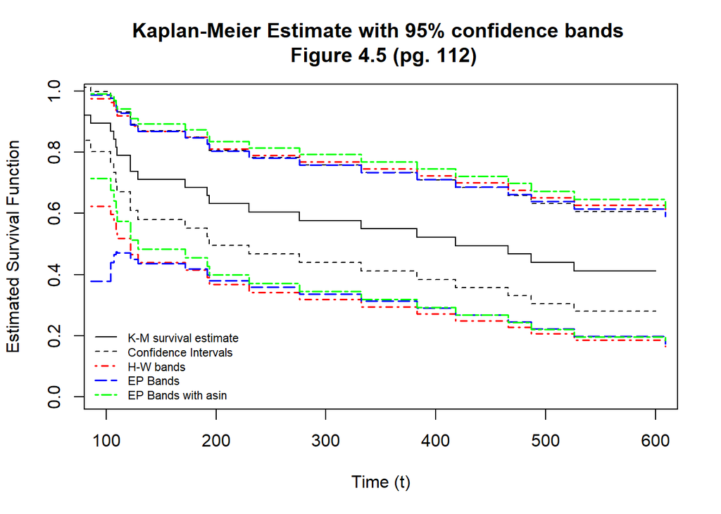

```r
#Plotting them
plot(my.surv, xlim = c(100, 600), main="Kaplan-Meier Estimate with 95% confidence bands \n Figure 4.5 (pg. 112)",
     xlab="Time (t)", ylab="Estimated Survival Function")

lines(ep.band$upper ~ ep.band$time, lty = 4, col = "red", lwd = 1.5, type = 's')
lines(ep.band$lower ~ ep.band$time, lty = 4, col = "red", lwd = 1.5, type = 's')

lines(hw.band$upper ~ hw.band$time, lty = 5, col = "blue", lwd = 1.5, type = 's')
lines(hw.band$lower ~ hw.band$time, lty = 5, col = "blue", lwd = 1.5, type = 's')

lines(ep.sin.band$LL ~ ep.sin.band$t, lty = 6, col = "green", lwd = 1.5, type = 's')
lines(ep.sin.band$UL ~ ep.sin.band$t, lty = 6, col = "green", lwd = 1.5, type = 's')

legend("bottomleft", legend=
         c("K-M survival estimate",
           "Confidence Intervals",
           "H-W bands", "EP Bands",
           "EP Bands with asin"), lty=c(1, 2, 4, 5, 6),
       bty = "n", lwd = c(1, 1, 1.5, 1.5, 1.5), cex = .7,
       col = c("black", "black", "red", "blue", "green"))
```

## Left-Truncated Right-Censored Survival Data (Section 4.6)

Left truncation is a common problem in survival analysis. We will show how to incorporate left truncation into our product-limit estimates. Naturally, one would like to extend this to modeling (Cox’s proportional hazards model and accelerated failure time models). However, I am unaware of any ‘nice’ functions/packages that can incorporate left truncation. Let’s look at the Channing house dataset.

```r
data(channing)
```

For left truncation we actually need to alter the `Surv()` function. We will have two time arguments. The first would be the left-truncation time, and the second would be the observed survival time. We also need to include change the `type` argument from `right` (default) to counting.

```r
fit <- survfit(Surv(ageentry, age, death, type = 'counting') ~ 1, data = channing)
```

```
## Warning in Surv(ageentry, age, death, type = "counting"): Stop time must be >
## start time, NA created
```

```r
fit
```

```
## Call: survfit(formula = Surv(ageentry, age, death, type = "counting") ~
##     1, data = channing)
##
##    4 observations deleted due to missingness
## records   n.max n.start  events  median 0.95LCL 0.95UCL
##     458     202      11     176     991     898    1027
```

When we try to run this we see a warning. Some patients have equal entry and event times and thus we have a time to event of 0. Although R throws them away in the analysis, for cleanliness let us remove these subjects and re-run our model.

```r
channing <- channing[channing$time > 0,]
fit <- survfit(Surv(ageentry, age, death, type = 'counting') ~ 1,
               data = channing)
fit
```

```
## Call: survfit(formula = Surv(ageentry, age, death, type = "counting") ~
##     1, data = channing)
##
## records   n.max n.start  events  median 0.95LCL 0.95UCL
##     458     202      11     176     991     898    1027
```

```r
fit.m <- survfit(Surv(ageentry, age, death, type='counting') ~ 1,
                 data = channing, subset = (gender == 1))
fit.f <- survfit(Surv(ageentry, age, death, type='counting') ~ 1,
                 data = channing, subset = (gender == 2))
head(fit.m$n.risk)
```

```
## [1]  2  1 12 24 24 25
```

```r
head(fit.f$n.risk)
```

```
## [1] 17 21 28 33 35 36
```

We can see that the number at risk for males DOES reach 0. This is problematic, since the Kaplan Meier Product-Limit Estimate will be zero past this time. This is apparent when we look at the summary for males.

```r
summary(fit.m)
```

```
## Call: survfit(formula = Surv(ageentry, age, death, type = "counting") ~
##     1, data = channing, subset = (gender == 1))
##
##  time n.risk n.event censored survival std.err lower 95% CI upper 95% CI
##   777      2       1        0      0.5   0.354        0.125            1
##   781      1       1        0      0.0     NaN           NA           NA
##   869     24       1        2      0.0     NaN           NA           NA
##   872     25       1        0      0.0     NaN           NA           NA
##   876     25       1        0      0.0     NaN           NA           NA
##   893     33       1        0      0.0     NaN           NA           NA
##   894     33       1        0      0.0     NaN           NA           NA
##   898     32       1        1      0.0     NaN           NA           NA
##   907     34       1        1      0.0     NaN           NA           NA
##   909     33       1        0      0.0     NaN           NA           NA
##   911     33       1        1      0.0     NaN           NA           NA
```

[output cut: 32 more lines]

Here is a graphical summary of the number of subjects at risk as a function of age (in months).

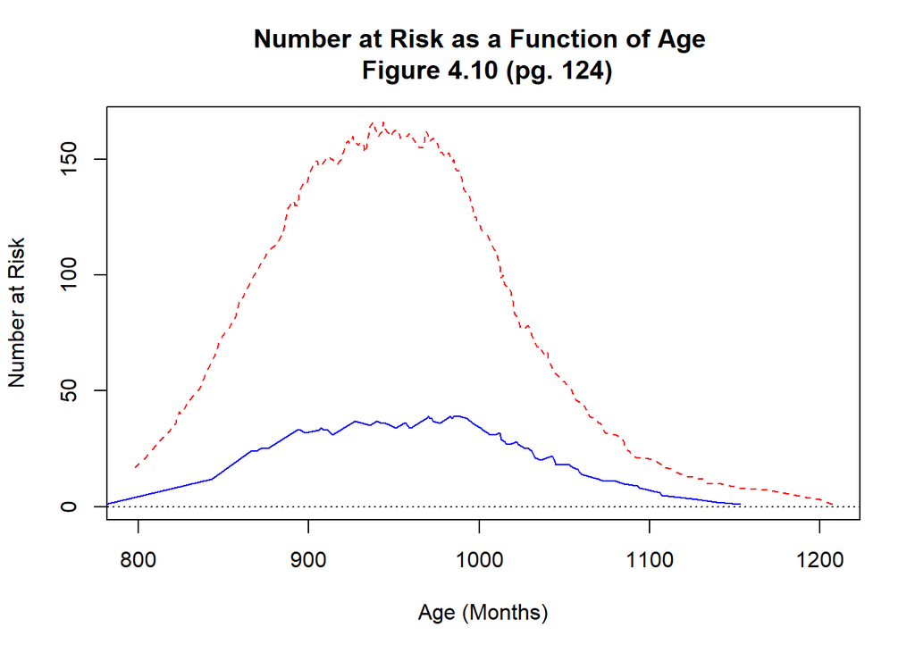

```r
plot(fit.f$n.risk ~ fit.f$time, type = 'l', lty = 2, col = 'red',
main = "Number at Risk as a Function of Age \n Figure 4.10 (pg. 124)", ylab = "Number at Risk", xlab = "Age (Months)")
lines(fit.m$n.risk ~ fit.m$time, lty = 1, type = 'l', col = 'blue')
abline(h = 0, lty = 3)
```

How can we avoid this? Instead of looking at the unconditional survival function, we can condition on patients surviving beyond t given survival past a.

$$\hat{S_a}(t) = \prod_{a \leq t_i \leq t} \left[1- \frac{d_i}{Y_i} \right], t \geq a$$

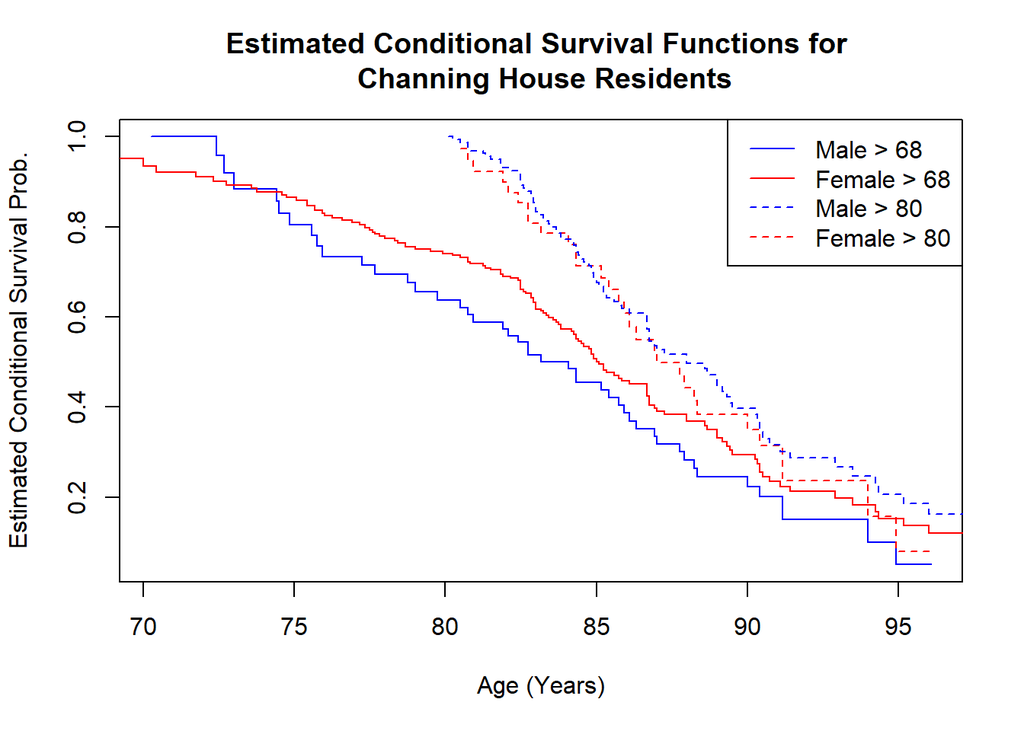

```r
# Condition on living past 68 and 80 years
fit.m2 <- survfit(Surv(ageentry, age, death, type='counting') ~ 1,
data = channing, subset = (gender== 1 & age > 68 * 12))
fit.f2 <- survfit(Surv(ageentry, age, death, type='counting') ~ 1,
data = channing, subset = (gender== 2 & age > 68 * 12))
fit.m3 <- survfit(Surv(ageentry, age, death, type='counting') ~ 1,
data = channing, subset = (gender== 1 & age > 80 * 12))
fit.f3 <- survfit(Surv(ageentry, age, death, type='counting') ~ 1,
data = channing, subset = (gender== 2 & age > 80 * 12))

plot(fit.m2$time/12, fit.m2$surv, type = 's', col = 'blue',
main = 'Estimated Conditional Survival Functions for \n Channing House Residents',
ylab = 'Estimated Conditional Survival Prob.', xlab = 'Age (Years)')
lines(fit.f2$time / 12, fit.f2$surv, type = 's', col = 'red')
lines(fit.m3$time / 12, fit.m3$surv, type = 's', col = 'red', lty = 2)
lines(fit.f3$time / 12, fit.f3$surv, type = 's', col = 'blue', lty = 2)
legend('topright', c('Male > 68', 'Female > 68', 'Male > 80', 'Female > 80'),
       col = c('blue', 'red', 'blue', 'red'),
       lty = c(1, 1, 2, 2))
```

## One-Sample Log-Rank Test (Section 7.2)

The log-rank test can be seen as a survival data analogy of the t-test for normal data or $\chi^2$-test for categorical data. In the one-sample case, we are interested in seeing if the population hazard rate is $h_0(t)$ for all $t \leq \tau$ for some given $\tau$. We can think of this as a goodness-of-fit type test. Does our data support the hypothesis that the population hazard is $h_0(t)$ or not? Performing this test is slightly tricky in `R`. We would need to specificy hypothesized survival probabilities for each observed survival time. Below is an example.

Consider the `alloauto` data. Suppose that it is know that for allogenic transplant patients the time from diagnosis to relapse or death has an exponential distribution with $\lambda = 0.03$. We can conduct a one-sample log-rank test to see if the hazard rate of the allogenic transplant patients is equal to $0.03$.

```r
data(alloauto)
head(alloauto)
```

```
##    time type delta
## 1 0.030    1     1
## 2 0.493    1     1
## 3 0.855    1     1
## 4 1.184    1     1
## 5 1.283    1     1
## 6 1.480    1     1
```

```r
timevar <- alloauto$time[alloauto$type == 1]
delta   <- alloauto$delta[alloauto$type == 1]

null_surv <- exp(-0.03 * timevar) #Expected survival probability

survdiff(Surv(timevar, delta) ~ offset(null_surv))
```

```
## Call:
## survdiff(formula = Surv(timevar, delta) ~ offset(null_surv))
##
## Observed Expected        Z        p
##   22.000   27.828    1.105    0.269
```

```r
rm(timevar, delta, null_surv)
```

## Log-Rank Test (Section 7.3)

When looking at two (or more) samples, interest is primarily in comparing quantities from these samples. We can conduct pointwise inference (e.g. $\hat{S}_1(t) = \hat{S}_2(t)$, or $\mu_1 = \mu_2$) rather easily.

In the two-sample case, assuming independence, standard software will give us estimates and corresponding standard errors for both samples. Therefore, $Z$-tests can be conducted to test whether the parameters of interest for both samples are equivalent or not.

However, much like confidence bands and confidence intervals, we are not interested in a *single point*, but rather, we are interested in seeing if two *rates* are equivalent throughout time.

The (weighted) log-rank test is used to compare the hypothesis if two (or more) hazard rates are the same for all $t \leq \tau$ for some given $\tau$. Usually $\tau$ is taken to be the largest time on study. Thus are hypothesis can be written as
$$H_0: h_1(t) = h_2(t) \hspace{.2in} \mbox{for all } t \leq \tau$$
.

The theoretical underpinnings of the weighted log-rank test come from the hypergeometric distribution (See Notes). Different weights have been proposed in the literature corresponding optimum power in different scenarios. For example, $W(t_i) = 1$ yields the usual *log-rank* test that corresponds to optimal power when assuming proportional hazards. **It is important to know which weights correspond to which assumptions (pg. 208)**.

The log-rank can be easily implemented in `R` through the `survdiff` function. However, there is a limited number of weights we can use in `survdiff`. Alternatively, we will take a look at another package in `R` called `survMisc` that extends the log-rank test for different weights. **SAS** also has more flexibility in this department as will be shown later.

Let’s look at Example 7.2 on pg. 209.

```r
data(kidney, package = "KMsurv")

head(kidney)
```

```
##   time delta type
## 1  1.5     1    1
## 2  3.5     1    1
## 3  4.5     1    1
## 4  4.5     1    1
## 5  5.5     1    1
## 6  8.5     1    1
```

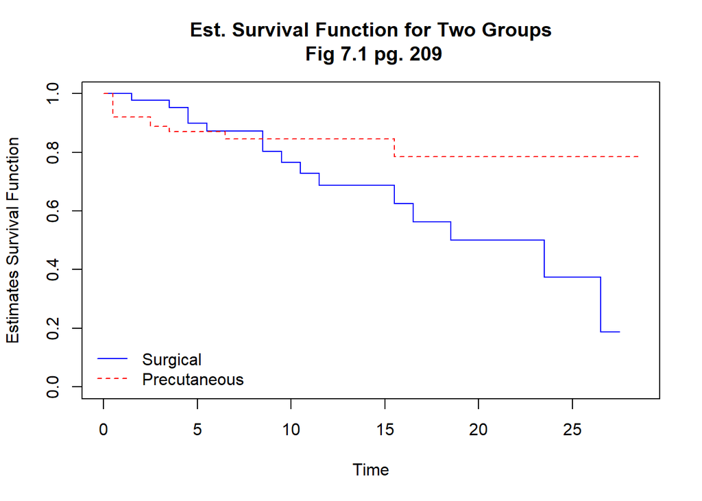

```r
#Graph the two survival functions
plot(survfit(Surv(time, delta) ~ type, data = kidney, conf.type = 'none'), lty = 1:2, col = c('blue', 'red'), main = ' Est. Survival Function for Two Groups \n Fig 7.1 pg. 209', ylab = 'Estimates Survival Function', xlab = 'Time')

legend('bottomleft', c('Surgical', 'Precutaneous'), col = c('blue', 'red'), lty = 1:2, bty = 'n')
```

```r
#Log-Rank Test (W = 1)
survdiff(Surv(time, delta) ~ type, data = kidney, rho = 0)
```

```
## Call:
## survdiff(formula = Surv(time, delta) ~ type, data = kidney, rho = 0)
##
##         N Observed Expected (O-E)^2/E (O-E)^2/V
## type=1 43       15       11      1.42      2.53
## type=2 76       11       15      1.05      2.53
##
##  Chisq= 2.5  on 1 degrees of freedom, p= 0.1
```

```r
#Log-Rank Test with Peto-Peto Weight
survdiff(Surv(time, delta) ~ type, data = kidney, rho = 1)
```

```
## Call:
## survdiff(formula = Surv(time, delta) ~ type, data = kidney, rho = 1)
##
##         N Observed Expected (O-E)^2/E (O-E)^2/V
## type=1 43     12.0     9.48     0.686      1.39
## type=2 76     10.4    12.98     0.501      1.39
##
##  Chisq= 1.4  on 1 degrees of freedom, p= 0.2
```

There may be other packages from CRAN that can perform log-rank tests using different weights. In any case, caution should be used when running those analyses (e.g. Compare results to SAS or textbook to make sure they agree).

One such alternative is the `comp` function in the `survMisc` package. This function calculates the log-rank test for the unweighted, Gehan-Breslow, Tarone-Ware, Peto-Peto, and Fleming-Harrington weights. Below is code on how to run the log-rank test using `comp`.

```r
library(survMisc)
fit <- ten(Surv(time, delta) ~ type, data = kidney) #Save as a "ten" object
comp(fit) #Calculates log-rank test statistics
```

```
##                      Q         Var         Z pNorm
## 1             -3.96355     6.23675 -1.587104     2
## n              9.00000 38919.18761  0.045621     6
## sqrtN        -13.20293   433.84450 -0.633875     5
## S1            -2.46920     4.37254 -1.180837     3
## S2            -2.31343     4.20869 -1.127672     4
## FH_p=1_q=1    -1.02064     0.10661 -3.125846     1
##               maxAbsZ        Var      Q pSupBr
## 1          3.9636e+00 6.2367e+00 1.5871      2
## n          2.8200e+02 3.8919e+04 1.4294      3
## sqrtN      2.6224e+01 4.3384e+02 1.2590      4
## S1         2.4692e+00 4.3725e+00 1.1808      5
## S2         2.3134e+00 4.2087e+00 1.1277      6
## FH_p=1_q=1 1.0206e+00 1.0661e-01 3.1258      1
```

From top to bottom we have the test statistics, `Q`, and the p-values, `pNorm` for the log-rank, Gehan-Breslow, Tarone-Ware, Peto-Peto, modified Peto-Peto, and Fleming-Harrington weights. The results are similar to that of Table 7.3 and from what we got with `survdiff`.

###Log-Rank Test for More than 2 Samples

Much like with $2 \times 2$ tables, we may want to stratify with respect to more than two samples. In such cases a stratified log-rank test can be ran. We can think of this as a survival data analog to ANOVA or the Mantel-Haenszel test.

Let’s look at the `bmt` example in Example 7.4. Here
$$H_0: h_{ALL}(t) = h_{LOW}(t) = h_{HIGH}(t) \hspace{.2in} \mbox{for all } t \leq \tau,$$
with an alternative that *at least* one of the populations has a different survival rate.

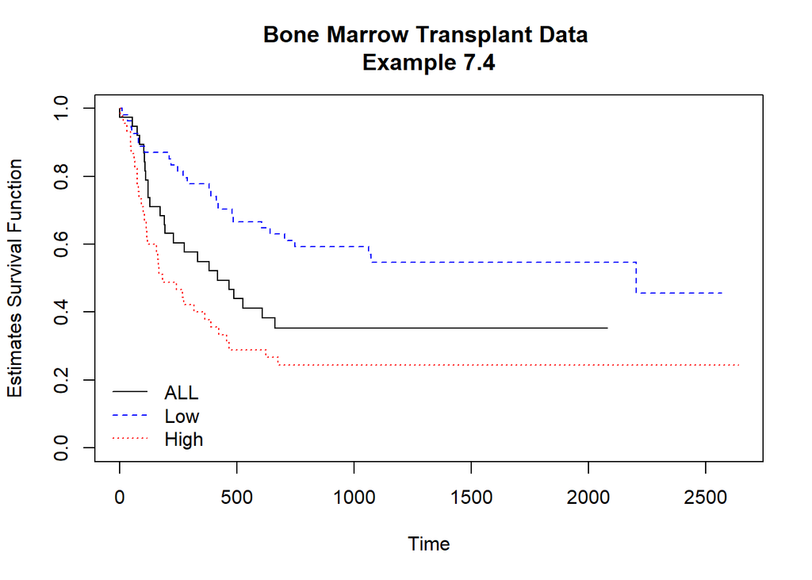

```r
data(bmt)

plot(survfit(Surv(t2, d3) ~ group, data = bmt, conf.type = 'none'),
     lty = 1:3, col = c('black', 'blue', 'red'),
     main = 'Bone Marrow Transplant Data \n Example 7.4 ', ylab = 'Estimates Survival Function',
     xlab = 'Time')

legend('bottomleft', c('ALL', 'Low', 'High'), col = c('black', 'blue', 'red'),
       lty = 1:3, bty = 'n')
```

```r
survdiff(Surv(t2, d3) ~ group, data = bmt)
```

```
## Call:
## survdiff(formula = Surv(t2, d3) ~ group, data = bmt)
##
##          N Observed Expected (O-E)^2/E (O-E)^2/V
## group=1 38       24     21.9     0.211     0.289
## group=2 54       25     40.0     5.604    11.012
## group=3 45       34     21.2     7.756    10.529
##
##  Chisq= 13.8  on 2 degrees of freedom, p= 0.001
```